# Flexibility and constraints in resource selection within a generalist pollinator guild

### We will focus on six species that are abundant and widespread:

1. *B. sensu-strictu*
2. *B. pascuorum*
3. *B. pratorum*
4. *B. hortorum*
5. *B. soroensis*
6. *B. wurflenii*

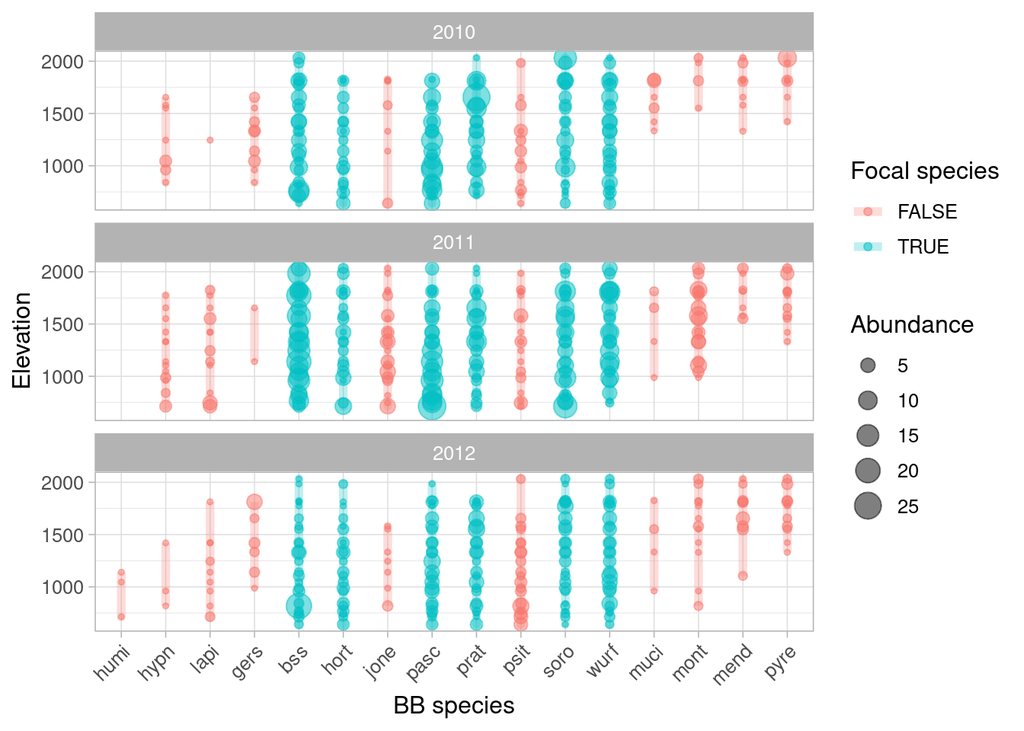

**Figure 1: Focal species**

### To improve readability, we will bin our floral taxa to family level.

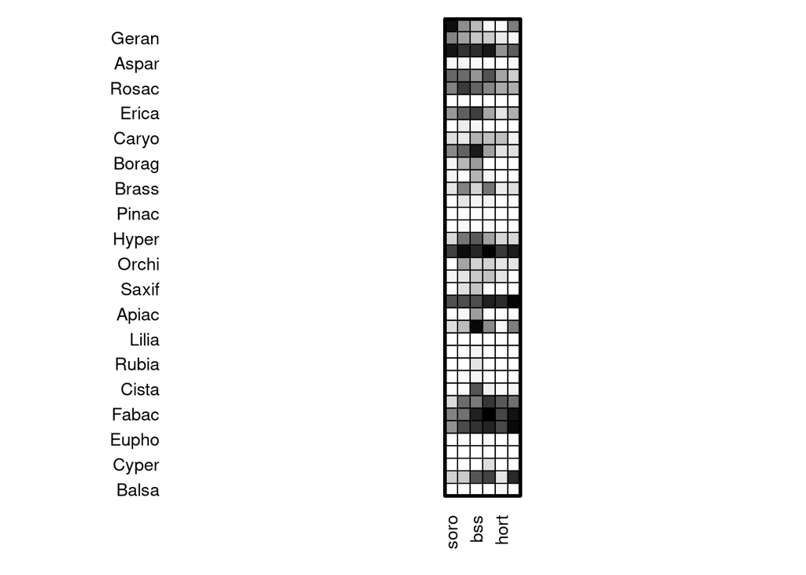

**Figure 2: Metaweb diagram**

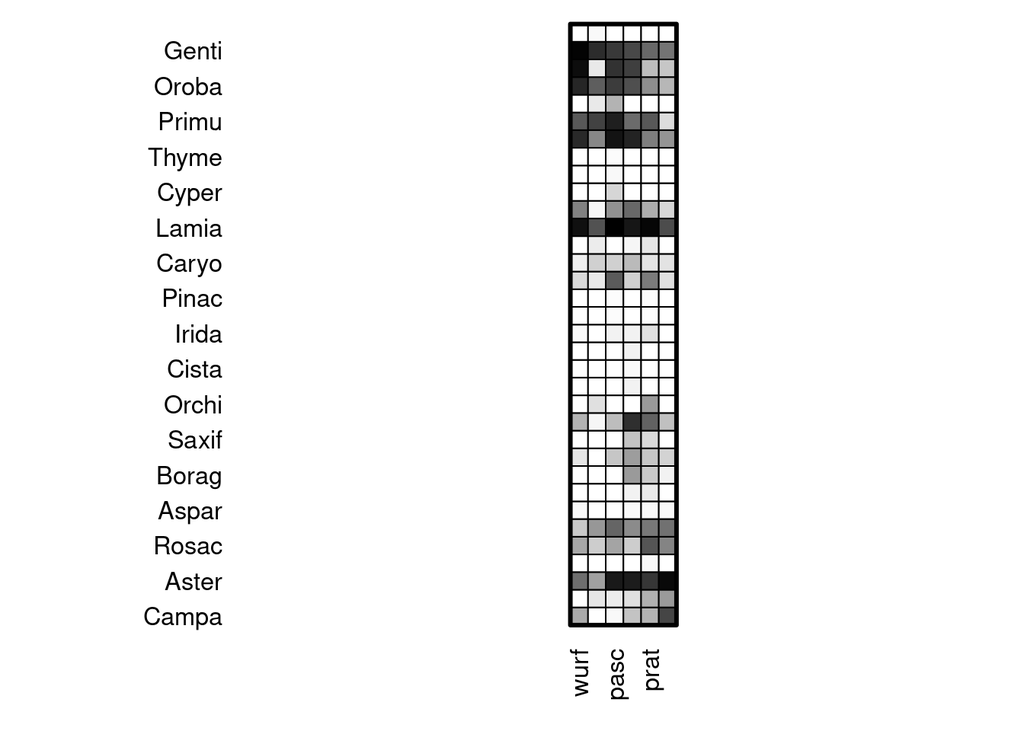

**Figure 2: Metaweb diagram**

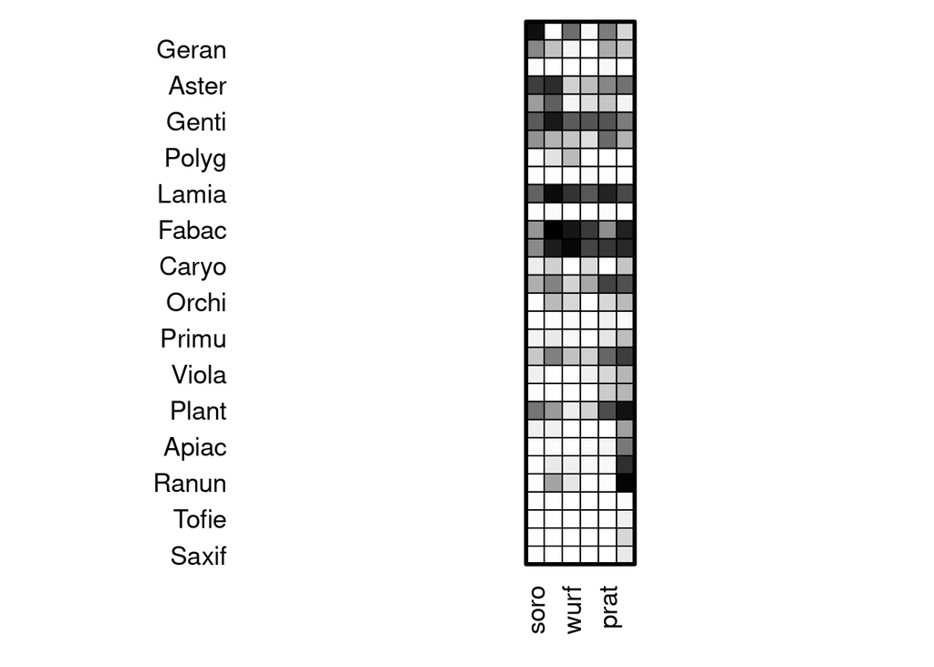

**Figure 2: Metaweb diagram**

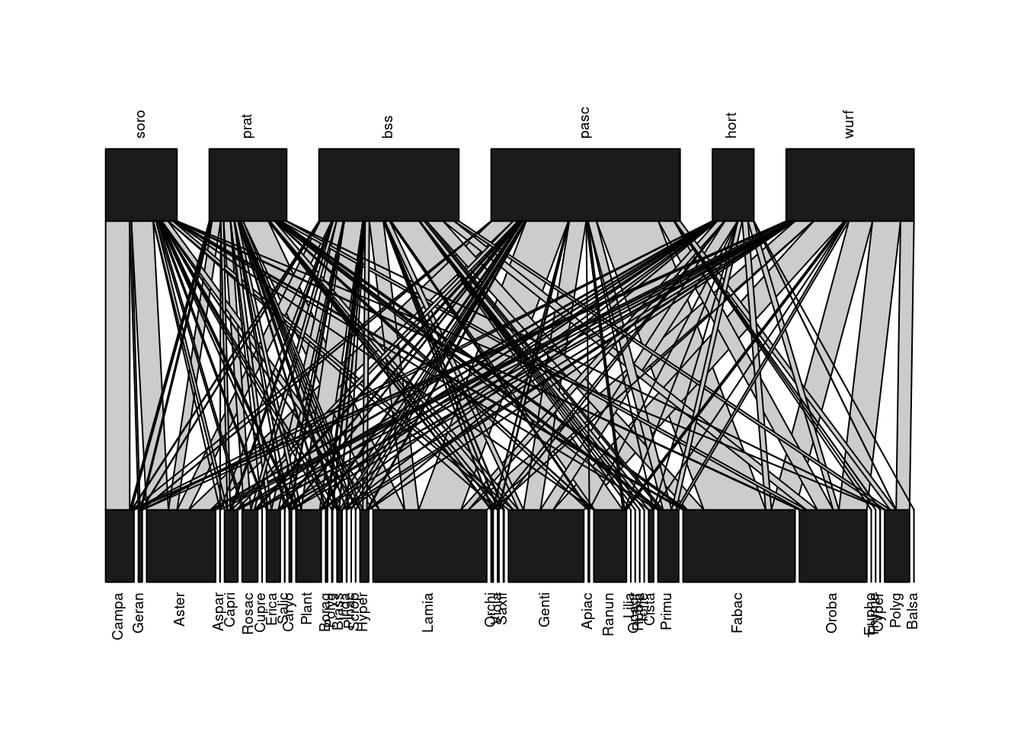

**Figure 2: Metaweb diagram**

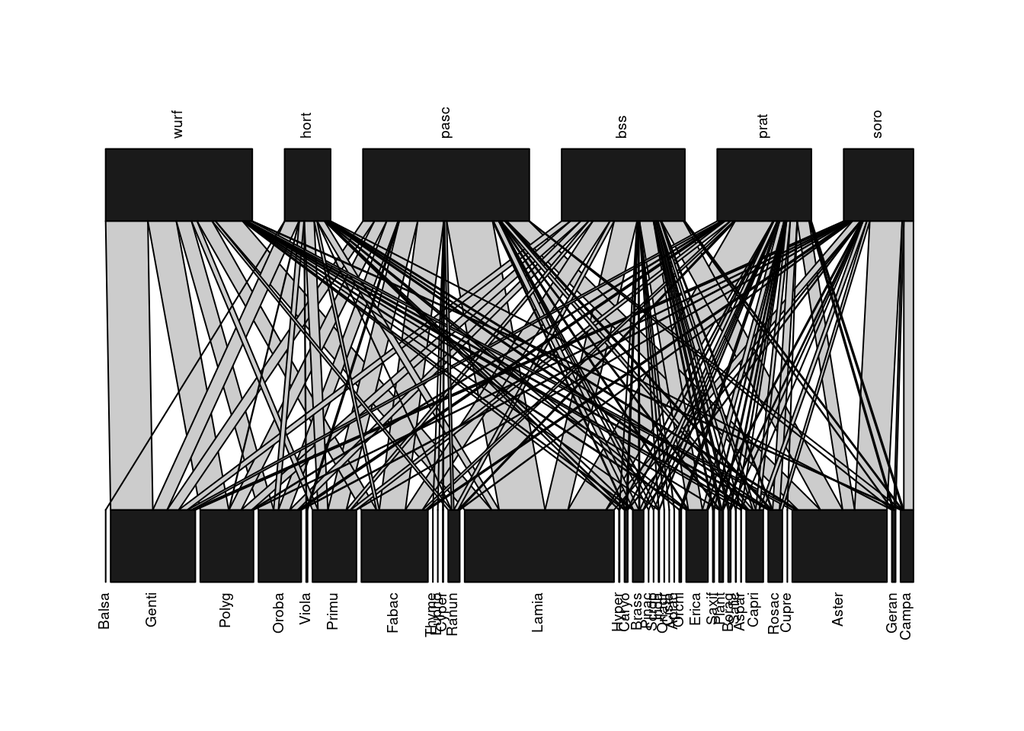

**Figure 2: Metaweb diagram**

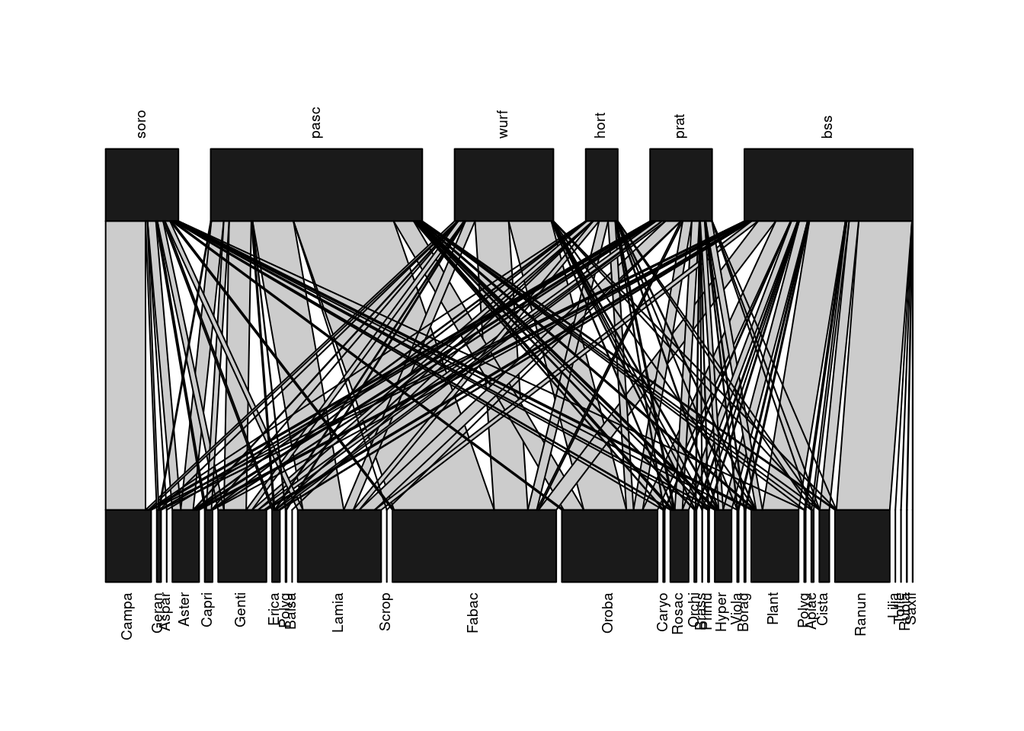

**Figure 2: Metaweb diagram**

### Question 1: Why do these bumble bee species partition the floral community as they do?

#### **H1: Tongue-length / corolla depth matching.** This is the classic explanation for resource partitioning in BB communities.

#### **H2: Competition.** It is also possble that competition could — perhaps transiently — drive BB species to partition floral resources according to some criterion other than tongue length matching. For example, several BB species may have very similar tongue lengths and yet show marked resource partitioning.

#### Others? Phylogenetic patterns could represent unmeasured floral trait variation, such as nutritional parameters / secondary chemistry / visual or olfactory cues and their corresponding traits in the BBs (physiology, perception). Differences in spatial foraging strategies? Differences in specialization, e.g. maybe some BB species can manage fewer floral species at a time.

### We can do a quick test of H1: I see no evidence that tongue length differences can explain dietary differences

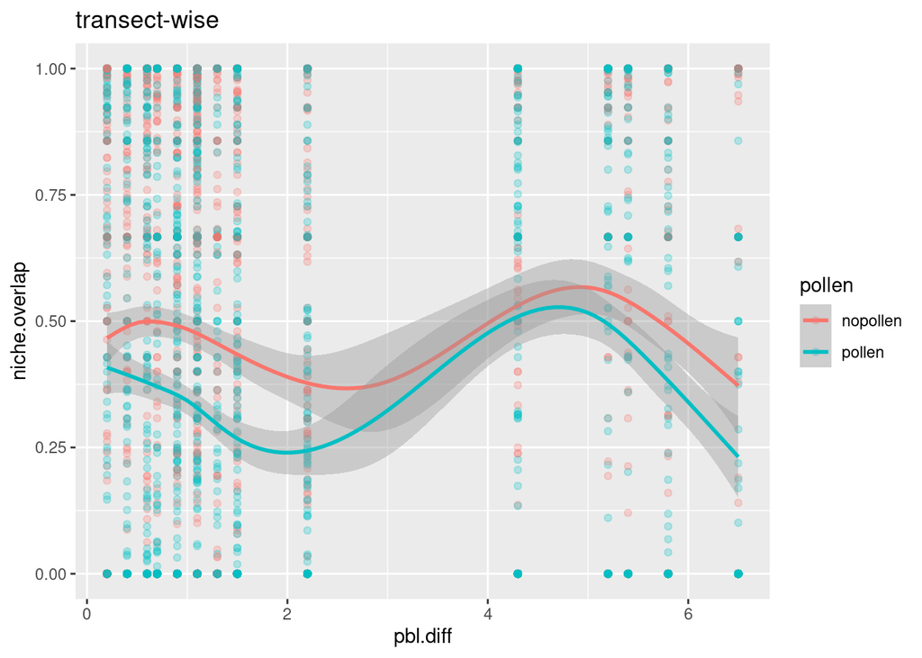

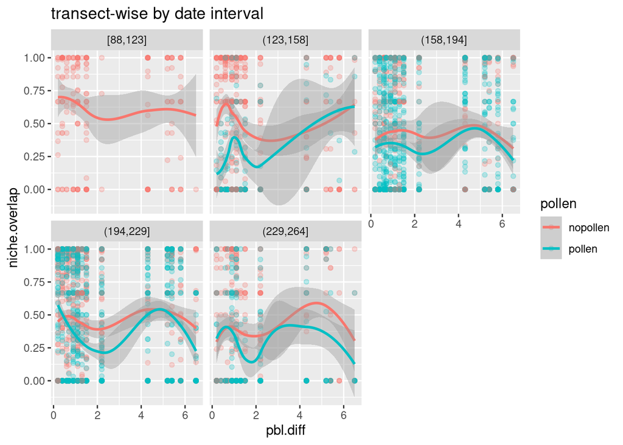

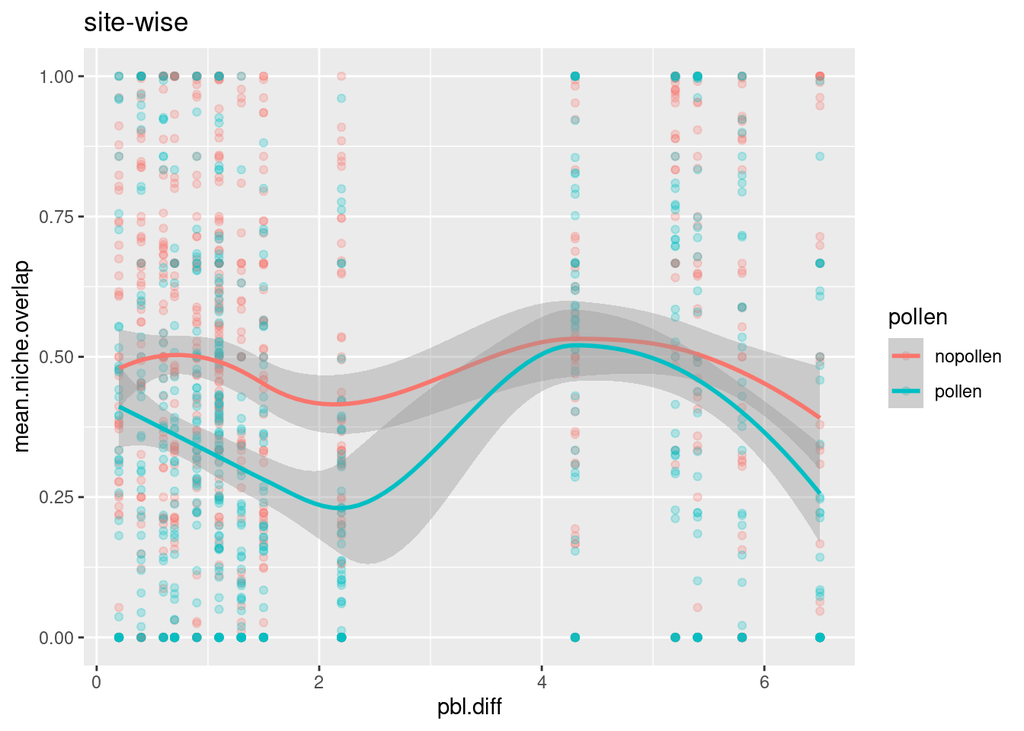

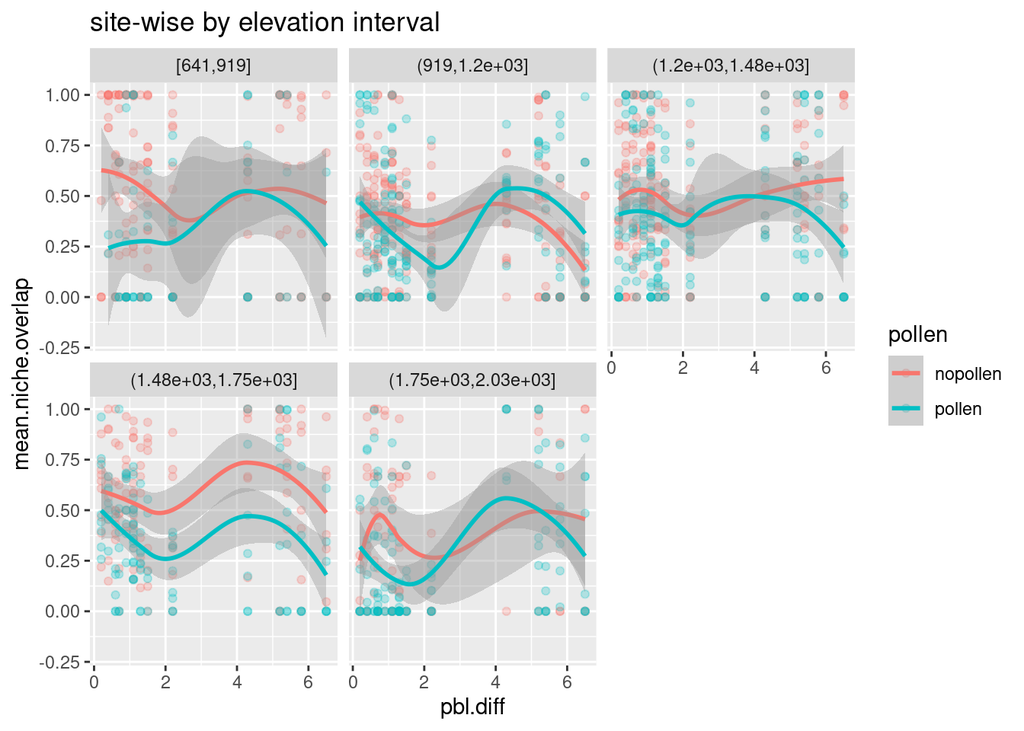